# Trabalho Prático II -

Grupo 4

04/December/2019

# Apresentação do caso de estudo

Este data set foi extraido no Kaggle, mas originalmente foi retirado do Instituto Nacional de Diabetes e Doenças Digestivas e Renais dos Estados Unidos. O objetivo deste conjunto de dados seria prever se um paciente tem ou não diabetes, baseado em determinadas medidas de diagnóstico incluídas no data set. Neste conjunto de dados estão presentes pacientes do género feminino com pelo menos 21 anos de idade e origem da povoação indigena Pima.

## O que é diabetes

A diabetes é uma doença metabólica crónica que se caracteriza por estados de hiperglicemia (níveis elevados de açúcar no sangue) constantes, os quais resultam de uma deficiência na produção/ secreção de insulina (hormona que atua na regulação da glicemia), de uma alteração na sua ação ou de ambas, resultando num metabolismo anormal dos macronutrientes ingeridos através da alimentação.

De um modo geral, a doença pode ser classificada em 3 categorias:

- Diabetes tipo 1: é uma doença autoimune, na qual o próprio sistema imune destrói as células pancreáticas produtoras de insulina. Por esse motivo, é também chamada de insulino-dependente, uma vez que a sobrevivência da pessoa depende da administração de insulina exógena;
- Diabetes tipo 2: devida à perda de função progressiva das células pancreáticas produtoras de insulina, resultando numa expressão menor de insulina. Está intimamente relacionada com a obesidade ou excesso de peso, maus hábitos alimentares e elevados níveis de sedentarismo;
- Diabetes gestacional: quando a anormalidade na glicemia é diagnosticada no 2º ou 3º trimestre da gravidez, sem diabetes prévia à gestação;

Existem ainda outros tipos específicos, associados a doenças que afetam a porção exócrina do pâncreas como fibrose cística, pancreatite ou induzidos por medicamentos como corticoides, imunossupressores ou anti-retrovirais, mas estes não são tão comuns.

Os valores de referência da diabetes ajudam a estabelecer condições de normoglicemia, hiperglicemia ou hipoglicemia e a fazer o diagnóstico da doença.

- NORMOGLICEMIA- É o mesmo que dizer que os valores da glicose estão dentro da normalidade. Para que os valores sejam considerados normais, a glicose deve estar os 80 mg/dl e os 140 mg/dl, dependendo se a análise foi feita em jejum ou após a refeição.
- HIPERGLICEMIA - Acontece quando os valores da glicose ultrapassam os valores normais, ou seja, os níveis de açúcar no sangue são altos. Isto acontece por três razões: o organismo produz insulina a menos, o organismo não utiliza bem a insulina ou uma combinação das duas.
- HIPOGLICEMIA - Por outro lado, quando os valores de açúcar estão baixos demais, os doentes podem ter sintomas como tremores, suores, fraqueza, batimentos cardíacos rápidos ou fortes, tonturas, visão dupla ou desmaios. Se não for detetada e tratada pode ter ainda consequências mais graves como lesões cerebrais ou morte. Se ingerir algo doce, como um sumo de fruta, os valores devem voltar à normalidade.

A tabela abaixo explica os valores de glicose 2 horas após a refeição

| VALORES DE REFERÊNCIA 2 HORAS APÓS A REFEIÇÃO |  |
| --- | --- |
| inferior 70 mg/dl | hipoglicemia |
| 70 mg/dl a 140 mg/dl | normal |
| 140 mg/dl a 199 mg/dl | pré-diabetes |
| superior 200 mg/dl | diabetes |

## Descrição dos dados

O dataset contém informações de 768 mulheres, das quais 268 mulheres foram diagnosticadas com diabetes. As informações disponíveis incluem 8 variáveis, tais como Idade, Número de gestações, Glicose, Insulina, etc. Uma descrição mais detalhada sobre as variáveis está exposta nos pontos abaixo. A variável de resposta no conjunto de dados é um classificador binário, *Outcome*, que indica se a pessoa foi diagnosticada com diabetes ou não.

- *Pregnancies*: Número de vezes que engravidou
- *Glucose*: Concentração de glicose no plasma durante 2 horas presente num teste de tolerância à glicose por via oral
- *BloodPressure*: Pressão sanguínea diastólica (mm Hg)
- *SkinThickness*: Espessura da dobra da pele do tríceps (mm)
- *Insulin*: Insulina sérica de 2 horas (mg/dl)
- BMI: índice de massa gorda (weight in kg/(height in m)2)
- *DiabetesPedigreeFunction*: Função de heretiedade do diabetes (uma função que pontua a probabilidade de diabetes com base no histórico familiar)
- *Age*: Idade (anos)
- *Outcome*: Variável de classe (0 se não diabético, 1 se diabético)

```r
library(readr)
diabetes <- read_csv("diabetes.csv")
attach(diabetes)
```

# Análise do *Dataset*

### Criação da variável “*Outcome*” como fator

```r
Outcome <- factor(diabetes$Outcome)
levels(Outcome) <- c("Não", "Sim")
is.factor(Outcome)
```

```
## [1] TRUE
```

```r
summary(Outcome)
```

```
## Não Sim
## 500 268
```

### Gráfico do *MissMap*

```r
library(Amelia)
sapply(diabetes, function (x) sum(is.na(x)))
```

```
##              Pregnancies                  Glucose            BloodPressure
##                        0                        0                        0
##            SkinThickness                  Insulin                      BMI
##                        0                        0                        0
## DiabetesPedigreeFunction                      Age                  Outcome
##                        0                        0                        0
```

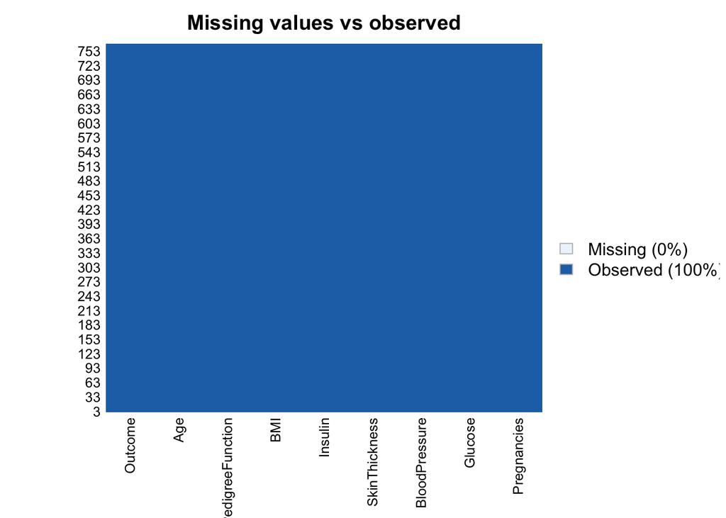

```r
#saber se existem missing values
data<- subset(diabetes,select=c(1,2,3,4,5,6,7,8,9))
missmap(data, main = "Missing values vs observed")
```

# Tratamento de dados

### Substituição dos Zeros em “NA”

- Transformar os zeros em NA
- Transformar os NA na média daquela coluna

Realçando o facto de que a variável da gravidez tem efetivamente 0 gravidezes e nesta variável não foi substituído o zero pela média. Desta forma conseguiu-se remover os zeros (que não faziam sentido) e conseguir assim, um *dataset* limpo e pronto a explorar.

```r
library(lattice)
missing_data <- diabetes[,setdiff(names(diabetes), c('Outcome', 'Pregnancies'))]
features_miss_num <- apply(missing_data, 2, function(x) sum(x <= 0))
features_miss <- names(missing_data)[ features_miss_num > 0]

rows_miss <- apply(missing_data, 1, function(x) sum(x <= 0) >= 1)
sum(rows_miss)
```

```
## [1] 376
```

```r
missing_data[missing_data <= 0] <- NA
diabetes[, names(missing_data)] <- missing_data


# KNN imputation
orig_data <- diabetes
colSums(is.na(diabetes))
```

```
##              Pregnancies                  Glucose            BloodPressure
##                        0                        5                       35
##            SkinThickness                  Insulin                      BMI
##                      227                      374                       11
## DiabetesPedigreeFunction                      Age                  Outcome
##                        0                        0                        0
```

```r
#diabetes[,c(-8)]
#diabetes <- diabetes[,c(-8)]

diabetes$Glucose[is.na(diabetes$Glucose)] <- mean(diabetes$Glucose,na.rm=T)
diabetes$Insulin[is.na(diabetes$Insulin)] <- mean(diabetes$Insulin,na.rm=T)
diabetes$SkinThickness[is.na(diabetes$SkinThickness)] <- mean(diabetes$SkinThickness,na.rm=T)
diabetes$BMI[is.na(diabetes$BMI)] <- mean(diabetes$BMI,na.rm=T)
diabetes$BloodPressure[is.na(diabetes$BloodPressure)] <- mean(diabetes$BloodPressure,na.rm=T)

View(diabetes)
```

## Análise da variável “Pregnancies”

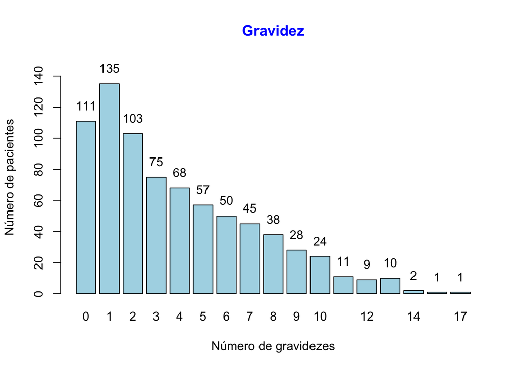

```r
grav <- c(111, 135,103,75,68,57,50,45,38,28,24,11,9,10,2,1,1)
 b <- barplot(grav,
 main = "Gravidez",
 xlab = "Número de gravidezes",
 ylab = "Número de pacientes",
 ylim = c(0,150),
 names.arg = c(0,1,2,3,4,5,6,7,8,9,10,11,12,13,14,15,17),
 col = c("lightblue"),
 col.main="blue",
 horiz = FALSE)
text(b,grav+10,labels=as.character(grav))
```

## Gráficos que relacionam a Gravidez com o resultado

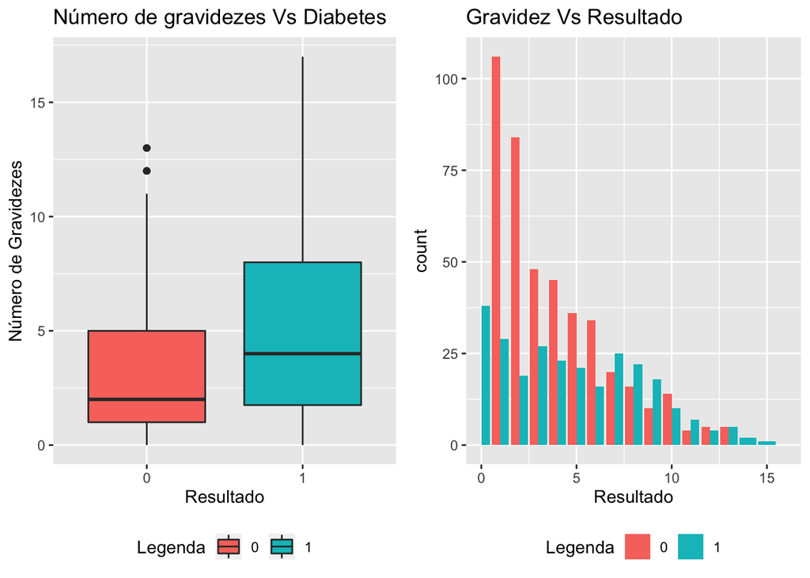

```r
library(ggplot2)
p1 <- ggplot(diabetes, aes(x = factor(diabetes$Outcome), y = Pregnancies, fill = factor(diabetes$Outcome))) +
  geom_boxplot() +
  theme(legend.position = "bottom") +
  labs (x = "Resultado") + labs (y ="Número de Gravidezes" ) + labs (fill = "Legenda") +
  ggtitle("Número de gravidezes Vs Diabetes")


p2 <- ggplot(diabetes,aes(x = Pregnancies, fill = factor(diabetes$Outcome))) +
  geom_bar(position = "Dodge") +
  scale_x_continuous(limits = c(0,16)) +
  labs (x = "Resultado") +
  labs (fill = "Legenda") +
  theme(legend.position = "bottom") +
  labs(title = "Gravidez Vs Resultado")


library(gridExtra)
gridExtra::grid.arrange(p1, p2, ncol = 2)
```

## Análise da variável “Glucose”

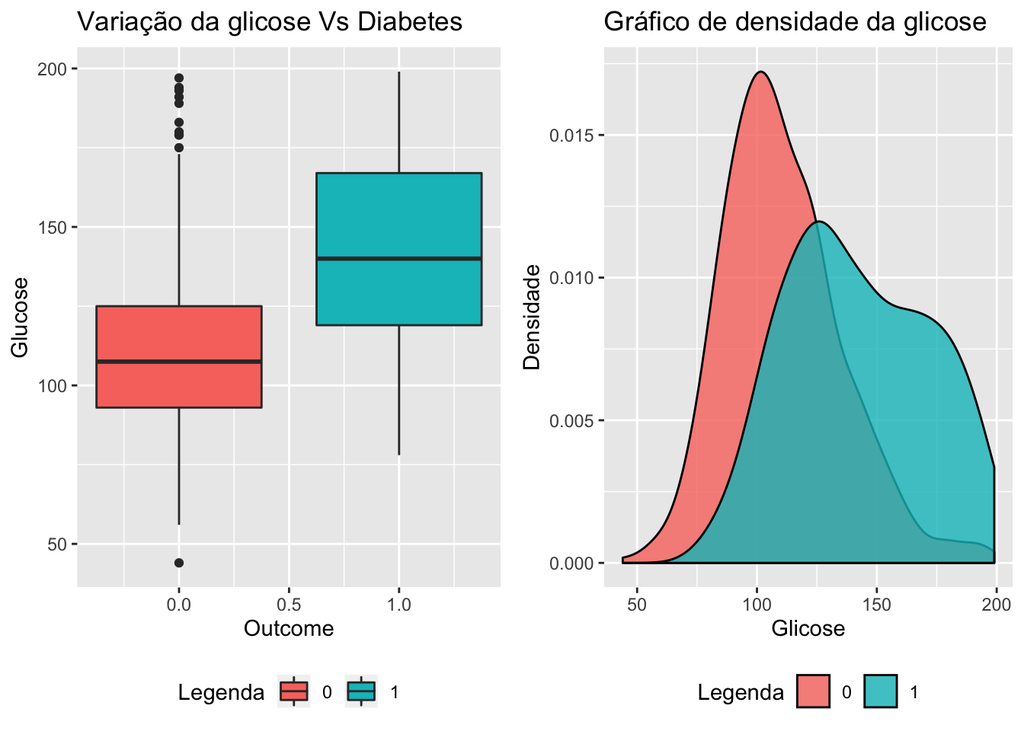

```r
p2 <- ggplot(diabetes, aes(x = Glucose, fill = factor(diabetes$Outcome))) +
  geom_density(alpha = 0.8) +
  theme(legend.position = "bottom") +
  labs (fill = "Legenda") +
  labs(x = "Glicose", y = "Densidade", title = "Gráfico de densidade da glicose")

p1 <- ggplot(diabetes, aes(x = Outcome, y = Glucose,fill = factor(diabetes$Outcome))) +
  geom_boxplot() +
  theme(legend.position = "bottom") +
  labs (fill = "Legenda") +
  ggtitle("Variação da glicose Vs Diabetes")

gridExtra::grid.arrange(p1, p2, ncol = 2)
```

## Análise da variável “Blood Pressure”

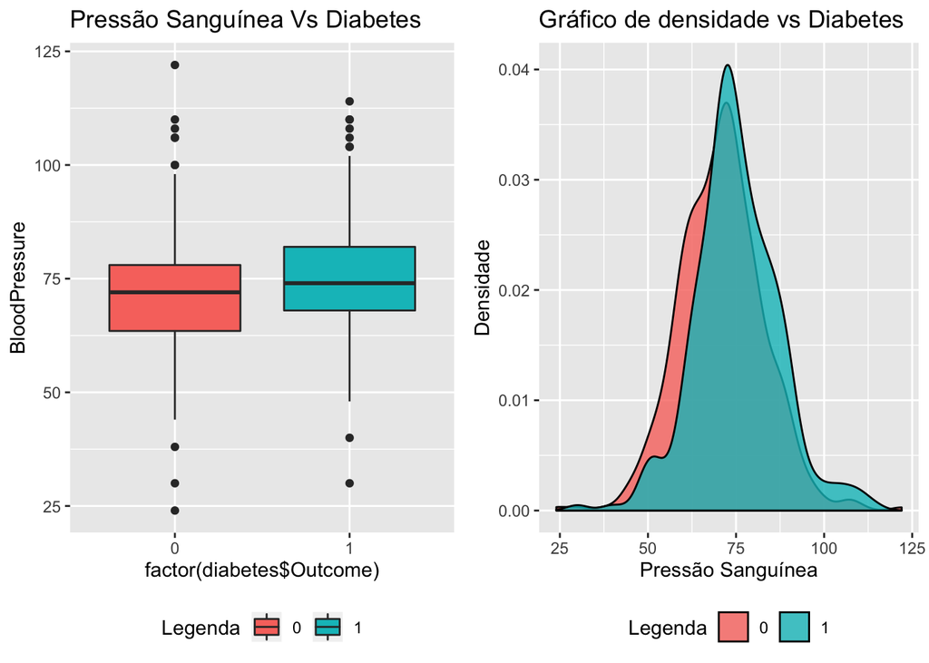

```r
p2 <- ggplot(diabetes, aes(x = BloodPressure, fill = factor(diabetes$Outcome))) +
  geom_density(alpha = 0.8) +
  theme(legend.position = "bottom") +
  labs (fill = "Legenda") +
  labs(x = "Pressão Sanguínea", y = "Densidade", title = "Gráfico de densidade vs Diabetes")

p1 <- ggplot(diabetes, aes(x = factor(diabetes$Outcome), y = BloodPressure,fill = factor(diabetes$Outcome))) +
  geom_boxplot() +
  theme(legend.position = "bottom") +
  labs (fill = "Legenda") +
  ggtitle("Pressão Sanguínea Vs Diabetes")

gridExtra::grid.arrange(p1, p2, ncol = 2)
```

## Análise da variável “SkinThickness”

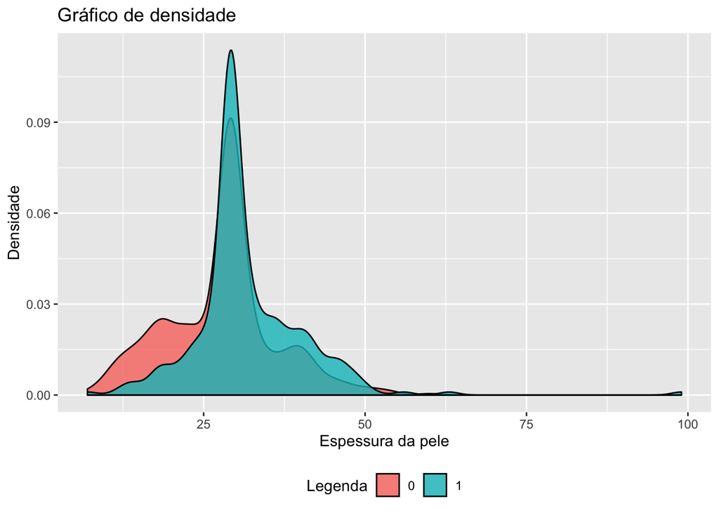

```r
ggplot(diabetes, aes(x = SkinThickness, fill = factor(diabetes$Outcome))) +
  geom_density(alpha = 0.8) +
  theme(legend.position = "bottom") +
  labs (fill = "Legenda") +
  labs(x = "Espessura da pele", y = "Densidade", title = "Gráfico de densidade")
```

## Análise da variável Insulina

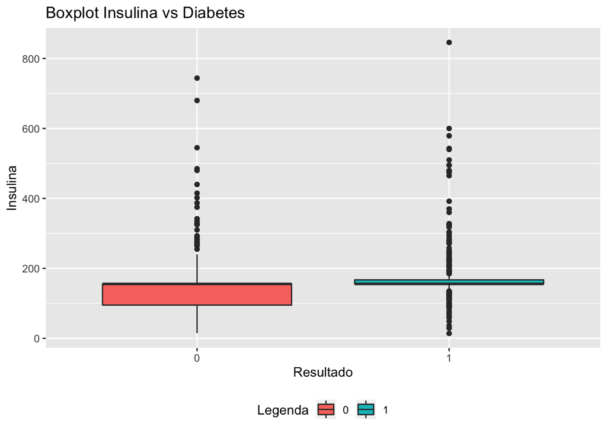

```r
library(ggplot2)
ggplot(diabetes, aes(x = factor(diabetes$Outcome), y = Insulin ,fill = factor(diabetes$Outcome))) +
  geom_boxplot() +
  theme(legend.position = "bottom") +
   labs (x = "Resultado") + labs (y ="Insulina" ) + labs (fill = "Legenda") +
  ggtitle("Boxplot Insulina vs Diabetes")
```

## Análise da variável BMI

O Índice de Massa Corporal (IMC) é um índice usado para a classificação do peso corporal em adultos, que relaciona o peso com a altura. A fórmula deste índice é definida pelo peso do indivíduo (em kilogramas) dividido pelo quadrado da sua altura (em metros). IMC= peso (kg) /altura (m)×altura (m). A Organização Mundial de Saúde (OMS) classifica a obesidade de acordo com os seguintes critérios:

| Classificação | IMC (kg/m2) |
| --- | --- |
| Baixo Peso | ≤ 18,5 |
| Peso normal | 18,5 a 24,9 |
| Pré-obesidade | 25 a 29,9 |
| Obesidade grau 1 | 30 a 34,9 |
| Obesidade grau 2 | 35 a 39,9 |
| Obesidade grau 3 | ≥ 40 |

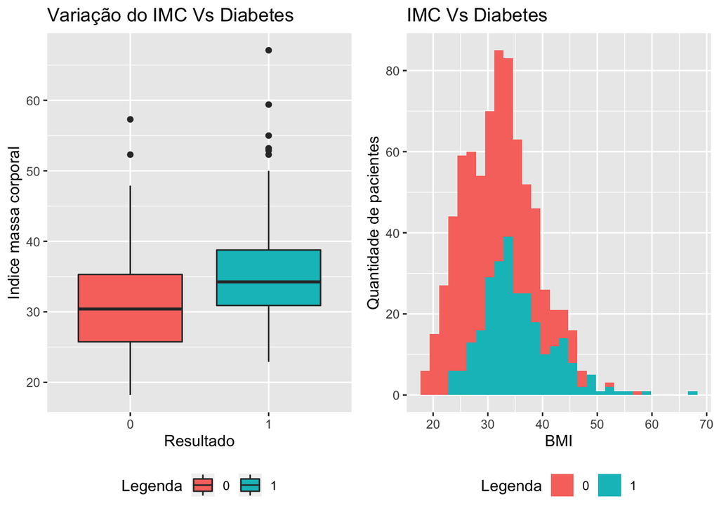

```r
p2 <- ggplot(diabetes, aes(BMI, fill = factor(diabetes$Outcome))) +
  geom_histogram() +
  theme(legend.position = "bottom") +
  labs(fill="Legenda") + labs(y="Quantidade de pacientes")+
  ggtitle("IMC Vs Diabetes")

p1 <- ggplot(diabetes, aes(x = factor(diabetes$Outcome), y = BMI, fill = factor(diabetes$Outcome))) +
  geom_boxplot() +
  theme(legend.position = "bottom") +
  labs(fill="Legenda") + labs (x = "Resultado") + labs (y ="Indice massa corporal" ) +
  ggtitle("Variação do IMC Vs Diabetes")

gridExtra::grid.arrange(p1, p2, ncol = 2)
```

## Relação da Gravidez com a idade vs diabetes

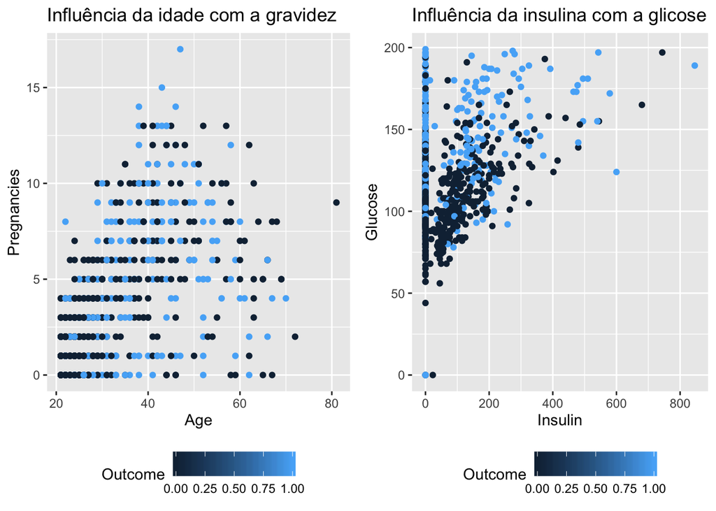

```r
p1 <- ggplot(diabetes, aes(x = Age, y = Pregnancies)) +
  geom_point(aes(color=Outcome)) +
  theme(legend.position = "bottom") +
  ggtitle("Influência da idade com a gravidez")

p2 <- ggplot(data,aes(x=Insulin,y=Glucose))+
  geom_point(aes(color=Outcome))+
  theme(legend.position = "bottom") +
  ggtitle("Influência da insulina com a glicose")

gridExtra::grid.arrange(p1, p2, ncol = 2)
```

```r
library(caret)
library(ggplot2)

# Prep Training e Test
set.seed(100)
trainDataIndex <- createDataPartition(Outcome, p=0.7, list = F) # 70% training data
train <- diabetes[trainDataIndex, ]
test <- diabetes[-trainDataIndex, ]

#Modelo
model <- glm(Outcome ~.,family=binomial(link='logit'),data=train)
summary(model)
```

```
##
## Call:
## glm(formula = Outcome ~ ., family = binomial(link = "logit"),
##     data = train)
##
## Deviance Residuals:
##     Min       1Q   Median       3Q      Max
## -2.5957  -0.7006  -0.3841   0.6853   2.3762
##
## Coefficients:
##                            Estimate Std. Error z value Pr(>|z|)
## (Intercept)              -9.6526443  0.9893468  -9.757  < 2e-16 ***
## Pregnancies               0.1185184  0.0387091   3.062   0.0022 **
## Glucose                   0.0375306  0.0047726   7.864 3.73e-15 ***
## BloodPressure            -0.0082741  0.0106001  -0.781   0.4351
## SkinThickness             0.0180122  0.0161984   1.112   0.2661
## Insulin                   0.0005201  0.0015363   0.339   0.7350
## BMI                       0.0921209  0.0218500   4.216 2.49e-05 ***
## DiabetesPedigreeFunction  0.8526290  0.3587499   2.377   0.0175 *
## Age                       0.0127746  0.0114296   1.118   0.2637
## ---
## Signif. codes:  0 '***' 0.001 '**' 0.01 '*' 0.05 '.' 0.1 ' ' 1
##
## (Dispersion parameter for binomial family taken to be 1)
##
##     Null deviance: 696.28  on 537  degrees of freedom
## Residual deviance: 487.84  on 529  degrees of freedom
## AIC: 505.84
##
## Number of Fisher Scoring iterations: 5
```

```r
library(tidyverse)
library(caret)
library(leaps)
library(tidyr)
library(dplyr)
library(MASS)
#ajuste completo do modelo
full.model <- glm(Outcome~.,family=binomial(link='logit'),data=train)

summary(full.model)
```

```
##
## Call:
## glm(formula = Outcome ~ ., family = binomial(link = "logit"),
##     data = train)
##
## Deviance Residuals:
##     Min       1Q   Median       3Q      Max
## -2.5957  -0.7006  -0.3841   0.6853   2.3762
##
## Coefficients:
##                            Estimate Std. Error z value Pr(>|z|)
## (Intercept)              -9.6526443  0.9893468  -9.757  < 2e-16 ***
## Pregnancies               0.1185184  0.0387091   3.062   0.0022 **
## Glucose                   0.0375306  0.0047726   7.864 3.73e-15 ***
## BloodPressure            -0.0082741  0.0106001  -0.781   0.4351
## SkinThickness             0.0180122  0.0161984   1.112   0.2661
## Insulin                   0.0005201  0.0015363   0.339   0.7350
## BMI                       0.0921209  0.0218500   4.216 2.49e-05 ***
## DiabetesPedigreeFunction  0.8526290  0.3587499   2.377   0.0175 *
## Age                       0.0127746  0.0114296   1.118   0.2637
## ---
## Signif. codes:  0 '***' 0.001 '**' 0.01 '*' 0.05 '.' 0.1 ' ' 1
##
## (Dispersion parameter for binomial family taken to be 1)
##
##     Null deviance: 696.28  on 537  degrees of freedom
## Residual deviance: 487.84  on 529  degrees of freedom
## AIC: 505.84
##
## Number of Fisher Scoring iterations: 5
```

```r
#método both
step.model <- stepAIC(full.model, direction = "both",
                      trace = FALSE)
summary(step.model)
```

```
##
## Call:
## glm(formula = Outcome ~ Pregnancies + Glucose + BMI + DiabetesPedigreeFunction,
##     family = binomial(link = "logit"), data = train)
##
## Deviance Residuals:
##     Min       1Q   Median       3Q      Max
## -2.6747  -0.6953  -0.3913   0.6805   2.4436
##
## Coefficients:
##                           Estimate Std. Error z value Pr(>|z|)
## (Intercept)              -9.621241   0.870052 -11.058  < 2e-16 ***
## Pregnancies               0.138771   0.032632   4.253 2.11e-05 ***
## Glucose                   0.038529   0.004343   8.871  < 2e-16 ***
## BMI                       0.098387   0.018162   5.417 6.05e-08 ***
## DiabetesPedigreeFunction  0.870905   0.356583   2.442   0.0146 *
## ---
## Signif. codes:  0 '***' 0.001 '**' 0.01 '*' 0.05 '.' 0.1 ' ' 1
##
## (Dispersion parameter for binomial family taken to be 1)
##
##     Null deviance: 696.28  on 537  degrees of freedom
## Residual deviance: 491.04  on 533  degrees of freedom
## AIC: 501.04
##
## Number of Fisher Scoring iterations: 5
```

```r
#método backward
step.modelb <- stepAIC(full.model, direction = "backward",
                      trace = FALSE)
summary(step.modelb)
```

```
##
## Call:
## glm(formula = Outcome ~ Pregnancies + Glucose + BMI + DiabetesPedigreeFunction,
##     family = binomial(link = "logit"), data = train)
##
## Deviance Residuals:
##     Min       1Q   Median       3Q      Max
## -2.6747  -0.6953  -0.3913   0.6805   2.4436
##
## Coefficients:
##                           Estimate Std. Error z value Pr(>|z|)
## (Intercept)              -9.621241   0.870052 -11.058  < 2e-16 ***
## Pregnancies               0.138771   0.032632   4.253 2.11e-05 ***
## Glucose                   0.038529   0.004343   8.871  < 2e-16 ***
## BMI                       0.098387   0.018162   5.417 6.05e-08 ***
## DiabetesPedigreeFunction  0.870905   0.356583   2.442   0.0146 *
## ---
## Signif. codes:  0 '***' 0.001 '**' 0.01 '*' 0.05 '.' 0.1 ' ' 1
##
## (Dispersion parameter for binomial family taken to be 1)
##
##     Null deviance: 696.28  on 537  degrees of freedom
## Residual deviance: 491.04  on 533  degrees of freedom
## AIC: 501.04
##
## Number of Fisher Scoring iterations: 5
```

```r
#método forward
step.modelf <- stepAIC(full.model, direction = "forward",
                       trace = FALSE)
summary(step.modelf)
```

```
##
## Call:
## glm(formula = Outcome ~ Pregnancies + Glucose + BloodPressure +
##     SkinThickness + Insulin + BMI + DiabetesPedigreeFunction +
##     Age, family = binomial(link = "logit"), data = train)
##
## Deviance Residuals:
##     Min       1Q   Median       3Q      Max
## -2.5957  -0.7006  -0.3841   0.6853   2.3762
##
## Coefficients:
##                            Estimate Std. Error z value Pr(>|z|)
## (Intercept)              -9.6526443  0.9893468  -9.757  < 2e-16 ***
## Pregnancies               0.1185184  0.0387091   3.062   0.0022 **
## Glucose                   0.0375306  0.0047726   7.864 3.73e-15 ***
## BloodPressure            -0.0082741  0.0106001  -0.781   0.4351
## SkinThickness             0.0180122  0.0161984   1.112   0.2661
## Insulin                   0.0005201  0.0015363   0.339   0.7350
## BMI                       0.0921209  0.0218500   4.216 2.49e-05 ***
## DiabetesPedigreeFunction  0.8526290  0.3587499   2.377   0.0175 *
## Age                       0.0127746  0.0114296   1.118   0.2637
## ---
## Signif. codes:  0 '***' 0.001 '**' 0.01 '*' 0.05 '.' 0.1 ' ' 1
##
## (Dispersion parameter for binomial family taken to be 1)
##
##     Null deviance: 696.28  on 537  degrees of freedom
## Residual deviance: 487.84  on 529  degrees of freedom
## AIC: 505.84
##
## Number of Fisher Scoring iterations: 5
```

```r
#verificar qual o que tem menor AIC
AIC(step.model)
```

```
## [1] 501.0397
```

```r
AIC(step.modelb)
```

```
## [1] 501.0397
```

```r
AIC(step.modelf)
```

```
## [1] 505.8351
```

```r
models <- regsubsets(Outcome~., data=train, nvmax = 8, method = "seqrep")
summary(models)
```

```
## Subset selection object
## Call: regsubsets.formula(Outcome ~ ., data = train, nvmax = 8, method = "seqrep")
## 8 Variables  (and intercept)
##                          Forced in Forced out
## Pregnancies                  FALSE      FALSE
## Glucose                      FALSE      FALSE
## BloodPressure                FALSE      FALSE
## SkinThickness                FALSE      FALSE
## Insulin                      FALSE      FALSE
## BMI                          FALSE      FALSE
## DiabetesPedigreeFunction     FALSE      FALSE
## Age                          FALSE      FALSE
## 1 subsets of each size up to 8
## Selection Algorithm: 'sequential replacement'
##          Pregnancies Glucose BloodPressure SkinThickness Insulin BMI
## 1  ( 1 ) " "         "*"     " "           " "           " "     " "
## 2  ( 1 ) " "         "*"     " "           " "           " "     "*"
## 3  ( 1 ) "*"         "*"     "*"           " "           " "     " "
## 4  ( 1 ) "*"         "*"     " "           " "           " "     "*"
## 5  ( 1 ) "*"         "*"     " "           "*"           " "     "*"
## 6  ( 1 ) "*"         "*"     " "           "*"           " "     "*"
## 7  ( 1 ) "*"         "*"     " "           "*"           "*"     "*"
## 8  ( 1 ) "*"         "*"     "*"           "*"           "*"     "*"
##          DiabetesPedigreeFunction Age
## 1  ( 1 ) " "                      " "
## 2  ( 1 ) " "                      " "
## 3  ( 1 ) " "                      " "
## 4  ( 1 ) "*"                      " "
## 5  ( 1 ) "*"                      " "
## 6  ( 1 ) "*"                      "*"
## 7  ( 1 ) "*"                      "*"
## 8  ( 1 ) "*"                      "*"
```

```r
#cross validation
set.seed(123)
# Set up repeated k-fold cross-validation
train.control <- trainControl(method = "cv", number = 10)
# Train the model
step.model <- train(Outcome~., data = diabetes,
                    method = "leapBackward",
                    tuneGrid = data.frame(nvmax = 1:8),
                    trControl = train.control)
# precisão do modelo - escolher o menor erro médio de previsão e MAE, R squared quanto maior melhor
step.model$results
```

```
##   nvmax      RMSE  Rsquared       MAE     RMSESD RsquaredSD      MAESD
## 1     1 0.4146791 0.2460671 0.3490638 0.02689341 0.08522940 0.02481694
## 2     2 0.4032647 0.2865005 0.3345655 0.02632805 0.08429283 0.02612810
## 3     3 0.3960788 0.3131653 0.3263245 0.02699987 0.08388605 0.02435299
## 4     4 0.3949454 0.3183682 0.3248639 0.02544251 0.07718593 0.02320229
## 5     5 0.3956148 0.3160659 0.3255237 0.02577108 0.07783479 0.02348753
## 6     6 0.3959203 0.3145326 0.3259515 0.02500116 0.07569747 0.02332505
## 7     7 0.3965621 0.3124561 0.3265079 0.02507157 0.07396098 0.02326640
## 8     8 0.3967508 0.3119751 0.3266879 0.02492512 0.07331023 0.02311150
```

```r
#melhor modelo
step.model$bestTune
```

```
##   nvmax
## 4     4
```

```r
#coeficientes finais do modelo
coef(step.model$finalModel, 4)
```

```
##              (Intercept)              Pregnancies                  Glucose
##             -1.040095596              0.023765092              0.006470141
##                      BMI DiabetesPedigreeFunction
##              0.013789972              0.132996594
```

```r
summary(step.model$finalModel)
```

```
## Subset selection object
## 8 Variables  (and intercept)
##                          Forced in Forced out
## Pregnancies                  FALSE      FALSE
## Glucose                      FALSE      FALSE
## BloodPressure                FALSE      FALSE
## SkinThickness                FALSE      FALSE
## Insulin                      FALSE      FALSE
## BMI                          FALSE      FALSE
## DiabetesPedigreeFunction     FALSE      FALSE
## Age                          FALSE      FALSE
## 1 subsets of each size up to 4
## Selection Algorithm: backward
##          Pregnancies Glucose BloodPressure SkinThickness Insulin BMI
## 1  ( 1 ) " "         "*"     " "           " "           " "     " "
## 2  ( 1 ) " "         "*"     " "           " "           " "     "*"
## 3  ( 1 ) "*"         "*"     " "           " "           " "     "*"
## 4  ( 1 ) "*"         "*"     " "           " "           " "     "*"
##          DiabetesPedigreeFunction Age
## 1  ( 1 ) " "                      " "
## 2  ( 1 ) " "                      " "
## 3  ( 1 ) " "                      " "
## 4  ( 1 ) "*"                      " "
```

```r
view(diabetes)
```

```r
model2= glm(Outcome~ Pregnancies + Glucose + BMI + DiabetesPedigreeFunction,family=binomial(link='logit'),data=train)
summary(model2)
```

```
##
## Call:
## glm(formula = Outcome ~ Pregnancies + Glucose + BMI + DiabetesPedigreeFunction,
##     family = binomial(link = "logit"), data = train)
##
## Deviance Residuals:
##     Min       1Q   Median       3Q      Max
## -2.6747  -0.6953  -0.3913   0.6805   2.4436
##
## Coefficients:
##                           Estimate Std. Error z value Pr(>|z|)
## (Intercept)              -9.621241   0.870052 -11.058  < 2e-16 ***
## Pregnancies               0.138771   0.032632   4.253 2.11e-05 ***
## Glucose                   0.038529   0.004343   8.871  < 2e-16 ***
## BMI                       0.098387   0.018162   5.417 6.05e-08 ***
## DiabetesPedigreeFunction  0.870905   0.356583   2.442   0.0146 *
## ---
## Signif. codes:  0 '***' 0.001 '**' 0.01 '*' 0.05 '.' 0.1 ' ' 1
##
## (Dispersion parameter for binomial family taken to be 1)
##
##     Null deviance: 696.28  on 537  degrees of freedom
## Residual deviance: 491.04  on 533  degrees of freedom
## AIC: 501.04
##
## Number of Fisher Scoring iterations: 5
```

```r
library(yhat)
yhat=fitted.values(model2)

fitted.results <- predict(model2,newdata=subset(test,select=c(1,2,3,6,7)),type='response')
fitted.results <- ifelse(fitted.results > 0.5,1,0)
misClasificError <- mean(fitted.results != test$Outcome)
print(paste('Accuracy',1-misClasificError))
```

```
## [1] "Accuracy 0.752173913043478"
```

```r
library(tidyverse) # for data manipulation
library(dlstats)    # for package download stats
library(pkgsearch)
library(ROCR)
```

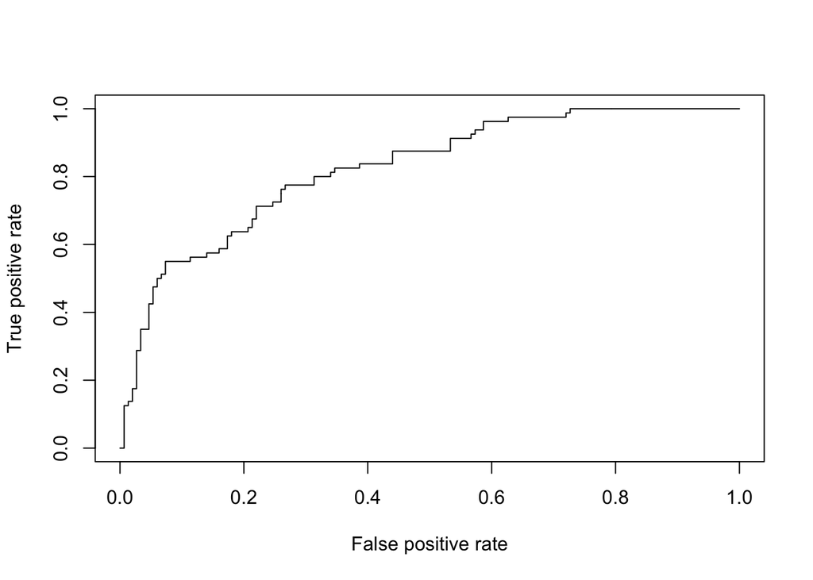

```r
library(gplots)


p <- predict(model2, newdata=subset(test,select=c(1,2,3,6,7)), type="response")
pr <- prediction(p, test$Outcome)
prf <- performance(pr, measure = "tpr", x.measure = "fpr")
plot(prf)
```

```r
auc <- performance(pr, measure = "auc")
auc <- auc@y.values[[1]]
auc
```

```
## [1] 0.8230833
```

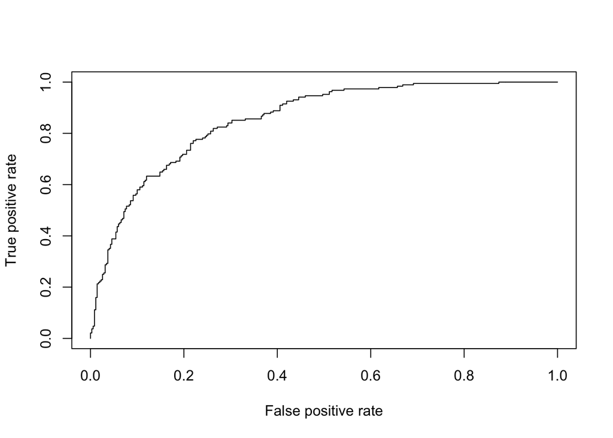

```r
library(yhat)
pr_i <- prediction(yhat, train$Outcome)
prf_i <- performance(pr_i, measure = "tpr", x.measure = "fpr")
plot(prf_i)
```

```r
auc_i <- performance(pr_i, measure = "auc")
auc_i <- auc_i@y.values[[1]]
auc_i
```

```
## [1] 0.8537538
```